# Predicting Survival on the Titanic

Kat Devlin

2018年4月10日

This is my first attempt at predicting passengers’ survival on the Titantic, and it also happens to be my first ever submission to Kaggle.

## Explore the Data

```r
setwd("~/Desktop/Titanic_predict")
x <- read.csv("train.csv")
head(x)
```

```
##   PassengerId Survived Pclass
## 1           1        0      3
## 2           2        1      1
## 3           3        1      3
## 4           4        1      1
## 5           5        0      3
## 6           6        0      3
##                                                  Name    Sex Age SibSp
## 1                             Braund, Mr. Owen Harris   male  22     1
## 2 Cumings, Mrs. John Bradley (Florence Briggs Thayer) female  38     1
## 3                              Heikkinen, Miss. Laina female  26     0
## 4        Futrelle, Mrs. Jacques Heath (Lily May Peel) female  35     1
## 5                            Allen, Mr. William Henry   male  35     0
## 6                                    Moran, Mr. James   male  NA     0
##   Parch           Ticket    Fare Cabin Embarked
## 1     0        A/5 21171  7.2500              S
## 2     0         PC 17599 71.2833   C85        C
## 3     0 STON/O2. 3101282  7.9250              S
## 4     0           113803 53.1000  C123        S
## 5     0           373450  8.0500              S
## 6     0           330877  8.4583              Q
```

```r
# First I had to indulge my former middle school self who swooned over Leo & Kate Winslet in the movie version:
grep("Jack", x$Name, value=T)  # not Jack
```

```
## [1] "Brewe, Dr. Arthur Jackson"
```

```r
grep("Dawson", x$Name, value=T)
```

```
## character(0)
```

```r
grep("Rose", x$Name, value=T)  # not Rose
```

```
## [1] "Aks, Mrs. Sam (Leah Rosen)"
```

```r
grep("Calvert", x$Name, value=T)
```

```
## character(0)
```

*Sigh*, it looks like Rose & Jack were not on board. Alright, time to do actual analysis.

```r
library(Amelia)
missmap(x)  # age has missing values ...
library(YaleToolkit)
```

[figure not shown]

```r
whatis(x) # also shows missingness for age (177)
```

```
##    variable.name         type missing distinct.values precision
## 1    PassengerId      numeric       0             891     1e+00
## 2       Survived      numeric       0               2     1e+00
## 3         Pclass      numeric       0               3     1e+00
## 4           Name mixed factor       0             891        NA
## 5            Sex  pure factor       0               2        NA
## 6            Age      numeric     177              88     1e-02
## 7          SibSp      numeric       0               7     1e+00
## 8          Parch      numeric       0               7     1e+00
## 9         Ticket mixed factor       0             681        NA
## 10          Fare      numeric       0             248     1e-04
## 11         Cabin mixed factor       0             148        NA
## 12      Embarked  pure factor       0               4        NA
##                    min                max
## 1                    1                891
## 2                    0                  1
## 3                    1                  3
## 4  Abbing, Mr. Anthony Zimmerman, Mr. Leo
## 5               female               male
## 6                 0.42                 80
## 7                    0                  8
## 8                    0                  6
## 9               110152          WE/P 5735
## 10                   0           512.3292
## 11                                      T
## 12                                      S
```

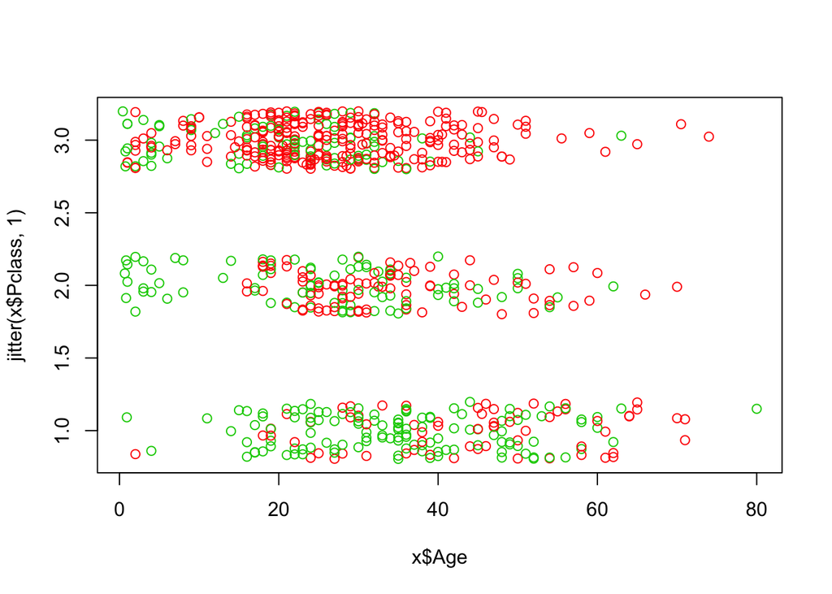

```r
# My gut says gender and age played large roles in who survived, a la "women and children first". Class probably did as well. So I'll make sex a dummy variable and plot away.
x$Sex.n <- as.numeric(x$Sex)
x$Sex.n[x$Sex.n==2] <- 0

plot(x$Age, jitter(x$Pclass, 1), col= x$Survived+2)
```

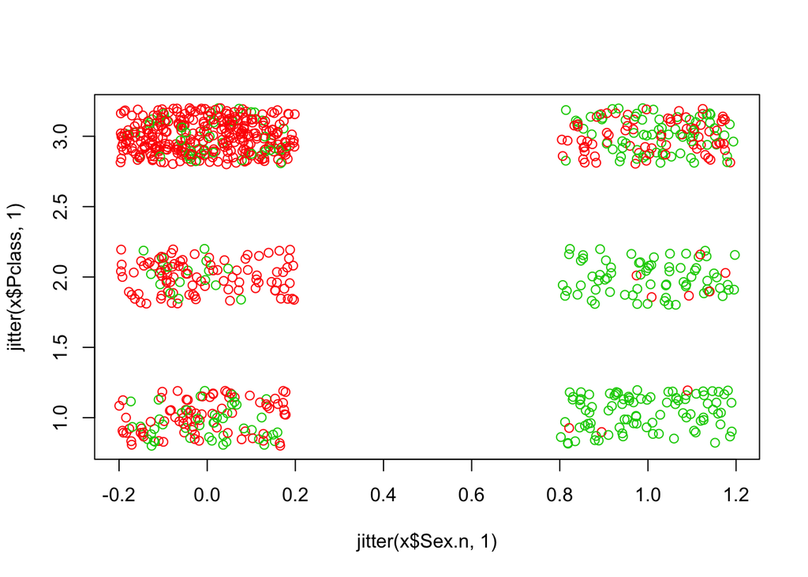

```r
plot(jitter(x$Sex.n, 1), jitter(x$Pclass, 1), col= x$Survived+2)
```

```r
# this is interesting

# Now I'll make a few more variables that might be worth exploring.
x$Age2 <- x$Age * x$Age
x$SexClass <- x$Sex.n * x$Pclass
x$alone <- as.numeric(x$SibSp==0 & x$Parch==0)
```

## Imputing with k-Nearest Neighbors

I still think age will be an important factor, so I want to try to fill in some missing values. Here I will use k-nearest neighbors with the training data only, then construct my model based off of that.

```r
w <- x  # make a copy in case we need to do more work on the original
whatis(w)
```

```
##    variable.name         type missing distinct.values precision
## 1    PassengerId      numeric       0             891     1e+00
## 2       Survived      numeric       0               2     1e+00
## 3         Pclass      numeric       0               3     1e+00
## 4           Name mixed factor       0             891        NA
## 5            Sex  pure factor       0               2        NA
## 6            Age      numeric     177              88     1e-02
## 7          SibSp      numeric       0               7     1e+00
## 8          Parch      numeric       0               7     1e+00
## 9         Ticket mixed factor       0             681        NA
## 10          Fare      numeric       0             248     1e-04
## 11         Cabin mixed factor       0             148        NA
## 12      Embarked  pure factor       0               4        NA
## 13         Sex.n      numeric       0               2     1e+00
## 14          Age2      numeric     177              88     1e-04
```

[output cut: 19 more lines]

```r
z <- w[, c("Pclass", "Sex.n", "SibSp", "Parch", "Fare", "SexClass", "alone")]
noage <- which(is.na(w$Age))
noage[1:4] # we'll use these as a check later
```

```
## [1]  6 18 20 27
```

```r
delta <- rep(NA, nrow(z))      # Not putting this as a column of z to avoid confusion.

top5q <-  5/length(delta)
for (j in noage) { # iterating over indices of missing values
  for (i in 1:nrow(z)) {
    delta[i] <- sum((z[j, ] - z[i, ])^2) # distance of i-th row to missing row
  }
  delta[noage] <- 100000
  s <- quantile(delta, top5q)
  nbs <- delta <= s
  w$Age[j] <- mean(w$Age[nbs])
}

w$Age[6]
```

```
## [1] 25.84615
```

```r
w$Age[18]
```

```
## [1] 31.77778
```

```r
w$Age[20]
```

```
## [1] 18.2
```

```r
w$Age[27]
```

```
## [1] 32.5
```

```r
whatis(w) # success
```

```
##    variable.name         type missing distinct.values precision
## 1    PassengerId      numeric       0             891     1e+00
## 2       Survived      numeric       0               2     1e+00
## 3         Pclass      numeric       0               3     1e+00
## 4           Name mixed factor       0             891        NA
## 5            Sex  pure factor       0               2        NA
## 6            Age      numeric       0             154     1e-13
## 7          SibSp      numeric       0               7     1e+00
## 8          Parch      numeric       0               7     1e+00
## 9         Ticket mixed factor       0             681        NA
## 10          Fare      numeric       0             248     1e-04
## 11         Cabin mixed factor       0             148        NA
## 12      Embarked  pure factor       0               4        NA
## 13         Sex.n      numeric       0               2     1e+00
## 14          Age2      numeric     177              88     1e-04
```

[output cut: 19 more lines]

```r
w$Age2 <- w$Age * w$Age  # add back in the square term
```

We have successfully imputed the age for all 177 missing cases.

## Logit Model for Predicting with Training Data

After toying around for a little while, I landed on the following logit model. With our binary dependent variable (survived or not) this made the most sense to me.

```r
glm.train3w <- glm(Survived ~ Age + Age2 + Pclass + Sex.n + SibSp + SexClass + alone,
                   family=binomial(link = "logit"), data=w)
summary(glm.train3w)
```

```
##
## Call:
## glm(formula = Survived ~ Age + Age2 + Pclass + Sex.n + SibSp +
##     SexClass + alone, family = binomial(link = "logit"), data = w)
##
## Deviance Residuals:
##     Min       1Q   Median       3Q      Max
## -3.5159  -0.6320  -0.4454   0.4528   2.4370
##
## Coefficients:
##               Estimate Std. Error z value Pr(>|z|)
## (Intercept)  3.0542232  0.5786078   5.279 1.30e-07 ***
## Age         -0.0989864  0.0236492  -4.186 2.84e-05 ***
## Age2         0.0008623  0.0003374   2.556   0.0106 *
## Pclass      -0.8295995  0.1457826  -5.691 1.27e-08 ***
## Sex.n        6.1993016  0.8981955   6.902 5.13e-12 ***
## SibSp       -0.6121585  0.1538385  -3.979 6.91e-05 ***
## SexClass    -1.4384752  0.3298870  -4.361 1.30e-05 ***
## alone       -0.5054426  0.2575146  -1.963   0.0497 *
## ---
## Signif. codes:  0 '***' 0.001 '**' 0.01 '*' 0.05 '.' 0.1 ' ' 1
##
## (Dispersion parameter for binomial family taken to be 1)
##
##     Null deviance: 1186.66  on 890  degrees of freedom
## Residual deviance:  751.73  on 883  degrees of freedom
## AIC: 767.73
##
## Number of Fisher Scoring iterations: 6
```

```r
# then I do a general diagnostic
library(pscl)
pR2(glm.train3w) # solid McFadden score in the .2-.4 range
```

```
##          llh      llhNull           G2     McFadden         r2ML
## -375.8664895 -593.3275684  434.9221579    0.3665110    0.3862258
##         r2CU
##    0.5247599
```

## Quick Test of Prediction Accuracy

Now that I feel good about my model, I want to do a quick test within the training dataset to see how good my predictions are given a known outcome. So I split the training data into train/test sets. (Yes this is becoming Inception with training data.)

```r
# test with k-nearest neighbors imputation
test0 <- w[1:400,]
train0 <- w[401:891,]

glm.train0 <- glm(Survived ~ Age + Age2 + Pclass + Sex.n + SibSp + SexClass + alone,
                  family=binomial(link = "logit"), data=train0)
summary(glm.train0)
```

```
##
## Call:
## glm(formula = Survived ~ Age + Age2 + Pclass + Sex.n + SibSp +
##     SexClass + alone, family = binomial(link = "logit"), data = train0)
##
## Deviance Residuals:
##     Min       1Q   Median       3Q      Max
## -3.4969  -0.6300  -0.4054   0.3307   2.3890
##
## Coefficients:
##               Estimate Std. Error z value Pr(>|z|)
## (Intercept)  4.5005304  0.8459344   5.320 1.04e-07 ***
## Age         -0.1257129  0.0321061  -3.916 9.02e-05 ***
## Age2         0.0012348  0.0004271   2.891 0.003843 **
## Pclass      -1.0559332  0.1932246  -5.465 4.63e-08 ***
## Sex.n        8.2608892  1.6655099   4.960 7.05e-07 ***
## SibSp       -0.9123173  0.2754453  -3.312 0.000926 ***
## SexClass    -2.3102426  0.5975487  -3.866 0.000111 ***
## alone       -0.9863015  0.3934555  -2.507 0.012184 *
## ---
## Signif. codes:  0 '***' 0.001 '**' 0.01 '*' 0.05 '.' 0.1 ' ' 1
##
## (Dispersion parameter for binomial family taken to be 1)
##
##     Null deviance: 650.54  on 490  degrees of freedom
## Residual deviance: 389.20  on 483  degrees of freedom
## AIC: 405.2
##
## Number of Fisher Scoring iterations: 6
```

```r
fitted.results <- predict(glm.train0, newdata=subset(test0,select=c(2,3,6,7,8,13,14,15,16)), type='response')
fitted.results <- ifelse(fitted.results > 0.5,1,0)

misClasificError <- mean(fitted.results != test0$Survived)
print(paste('Accuracy',1-misClasificError))
```

```
## [1] "Accuracy 0.78"
```

```r
# 78% correct classification
```

## Get Final Survival Predictions

That model seems to work fairly well, so now I want to bring in the Kaggle test data and get the actual predictions for contest submission.

```r
y <- read.csv("test.csv")
whatis(y) # 86 missing Age, 1 missing Fare (not used in my model)
```

```
##    variable.name         type missing distinct.values precision
## 1    PassengerId      numeric       0             418     1e+00
## 2         Pclass      numeric       0               3     1e+00
## 3           Name mixed factor       0             418        NA
## 4            Sex  pure factor       0               2        NA
## 5            Age      numeric      86              79     1e-02
## 6          SibSp      numeric       0               7     1e+00
## 7          Parch      numeric       0               8     1e+00
## 8         Ticket mixed factor       0             363        NA
## 9           Fare      numeric       1             169     1e-04
## 10         Cabin mixed factor       0              77        NA
## 11      Embarked  pure factor       0               3        NA
##                              min                 max
## 1                            892                1309
## 2                              1                   3
## 3  Abbott, Master. Eugene Joseph Zakarian, Mr. Ortin
## 4                         female                male
## 5                           0.17                  76
## 6                              0                   8
## 7                              0                   9
## 8                         110469         W.E.P. 5734
## 9                              0            512.3292
## 10                                                G6
## 11                             C                   S
```

```r
# variable tinkering again
y$Sex.n <- as.numeric(y$Sex)
y$Sex.n[y$Sex.n==2] <- 0
y$Age2 <- y$Age * y$Age
y$SexClass <- y$Sex.n * y$Pclass
y$alone <- as.numeric(y$SibSp==0 & y$Parch==0)
```

This time, I am going to impute the missing age values using both original data sets after binding them together.

```r
k1 <- x[, c("PassengerId", "Pclass", "Age", "Sex.n", "SibSp", "Parch", "Fare", "SexClass", "alone")]
k2 <- y[, c("PassengerId", "Pclass", "Age", "Sex.n", "SibSp", "Parch", "Fare", "SexClass", "alone")]
k <- rbind(k1, k2)  # This is all the observations with 263 missing Age
whatis(k)
```

```
##   variable.name    type missing distinct.values precision  min       max
## 1   PassengerId numeric       0            1309     1e+00 1.00 1309.0000
## 2        Pclass numeric       0               3     1e+00 1.00    3.0000
## 3           Age numeric     263              98     1e-02 0.17   80.0000
## 4         Sex.n numeric       0               2     1e+00 0.00    1.0000
## 5         SibSp numeric       0               7     1e+00 0.00    8.0000
## 6         Parch numeric       0               8     1e+00 0.00    9.0000
## 7          Fare numeric       1             281     1e-04 0.00  512.3292
## 8      SexClass numeric       0               4     1e+00 0.00    3.0000
## 9         alone numeric       0               2     1e+00 0.00    1.0000
```

```r
# There is a missing value for Fare now, too. Let's find it and change that.
which(is.na(k$Fare))  # row 1044
```

```
## [1] 1044
```

```r
k[1044,]  # older male in 3rd class.
```

```
##      PassengerId Pclass  Age Sex.n SibSp Parch Fare SexClass alone
## 1044        1044      3 60.5     0     0     0   NA        0     1
```

```r
median(k$Fare[k$Pclass==3], na.rm=T)
```

```
## [1] 8.05
```

```r
# We'll let his ticket cost $8.05.
k$Fare[c(1044)] <- 8.05
whatis(k) # no more missing fares.
```

```
##   variable.name    type missing distinct.values precision  min       max
## 1   PassengerId numeric       0            1309     1e+00 1.00 1309.0000
## 2        Pclass numeric       0               3     1e+00 1.00    3.0000
## 3           Age numeric     263              98     1e-02 0.17   80.0000
## 4         Sex.n numeric       0               2     1e+00 0.00    1.0000
## 5         SibSp numeric       0               7     1e+00 0.00    8.0000
## 6         Parch numeric       0               8     1e+00 0.00    9.0000
## 7          Fare numeric       0             281     1e-04 0.00  512.3292
## 8      SexClass numeric       0               4     1e+00 0.00    3.0000
## 9         alone numeric       0               2     1e+00 0.00    1.0000
```

```r
# Back to imputing.
u <- k[, c("Pclass", "Sex.n", "SibSp", "Parch", "Fare", "SexClass", "alone")]
noage <- which(is.na(k$Age))
noage[1:4] # to check on later
```

```
## [1]  6 18 20 27
```

```r
delta <- rep(NA, nrow(u))      # Not putting this as a column of z to avoid confusion.

top5q <-  5/length(delta)
# Warning: This step takes a while!
for (j in noage) { # iterating over indices of missing values
  for (i in 1:nrow(u)) {
    delta[i] <- sum((u[j, ] - u[i, ])^2) # distance of i-th row to missing row
  }
  delta[noage] <- 100000
  s <- quantile(delta, top5q)
  nbs <- delta <= s
  k$Age[j] <- mean(k$Age[nbs])
}
whatis(k)  # no more missingness in Age
```

```
##   variable.name    type missing distinct.values precision  min       max
## 1   PassengerId numeric       0            1309     1e+00 1.00 1309.0000
## 2        Pclass numeric       0               3     1e+00 1.00    3.0000
## 3           Age numeric       0             181     1e-13 0.17   80.0000
## 4         Sex.n numeric       0               2     1e+00 0.00    1.0000
## 5         SibSp numeric       0               7     1e+00 0.00    8.0000
## 6         Parch numeric       0               8     1e+00 0.00    9.0000
## 7          Fare numeric       0             281     1e-04 0.00  512.3292
## 8      SexClass numeric       0               4     1e+00 0.00    3.0000
## 9         alone numeric       0               2     1e+00 0.00    1.0000
```

```r
k2$Age <- k$Age[892:1309]
k2$Age2 <- k2$Age * k2$Age

fitted.results <- predict(glm.train3w, newdata=k2, type='response')
fitted.results <- ifelse(fitted.results > 0.5,1,0)
k2$Survived <- fitted.results  # adds the Survived predictions

a <- k2[c(1,9)]
#write.csv(a, file="prediction1.csv", row.names = F)

###-----End of Script-----###
```